# Evolutionary Rates & Selection Strength

### 3. Pairwise t-tests of Rate values

The `get_pwt_rates` will produce a table of pairwise t-tests for differences between the mean clockrate value in the posterior and the absolute rate for each tree node.

```r
## Get table of pairwise t-tests for difference between the posterior mean and the rate for each tree node
RateSign_tests<- get_pwt_rates(rate_table_clades_means, posterior3p)

## Show first 10 lines of table
t3<-head(RateSign_tests, 10)
kableExtra::kbl(t3, caption = "Combined log file") |>
  kableExtra::kable_styling(font_size = 15, full_width = FALSE, bootstrap_options = "striped", "condensed")
```

Combined log file

| clade | nodes | clock | relative rate | absolute rate (mean) | null | p.value |
| --- | --- | --- | --- | --- | --- | --- |
| Dipnomorpha | 1 | 1 | 0.943696 | 0.0118443 | 0.0118443 | 0 |
| Dipnomorpha | 2 | 1 | 1.065326 | 0.0133709 | 0.0133709 | 0 |
| Dipnomorpha | 3 | 1 | 1.182460 | 0.0148411 | 0.0148411 | 0 |
| Dipnomorpha | 4 | 1 | 1.229767 | 0.0154348 | 0.0154348 | 0 |
| Dipnomorpha | 5 | 1 | 1.230564 | 0.0154448 | 0.0154448 | 0 |
| Other | 6 | 1 | 0.658855 | 0.0082693 | 0.0082693 | 0 |
| Other | 7 | 1 | 0.603090 | 0.0075694 | 0.0075694 | 0 |
| Osteolepididae | 8 | 1 | 0.843373 | 0.0105852 | 0.0105852 | 0 |
| Osteolepididae | 9 | 1 | 0.872012 | 0.0109446 | 0.0109446 | 0 |
| Osteolepididae | 10 | 1 | 0.811473 | 0.0101848 | 0.0101848 | 0 |

```r
## Export the table
write.csv(RateSign_tests, file="RateSign_tests.csv")
```

### 4. Plot selection gradient on the summary tree

Using different thresholds, Identify the strength (or mode) across branches in the tree for each clock partition with `plot_treerates_sgn`.

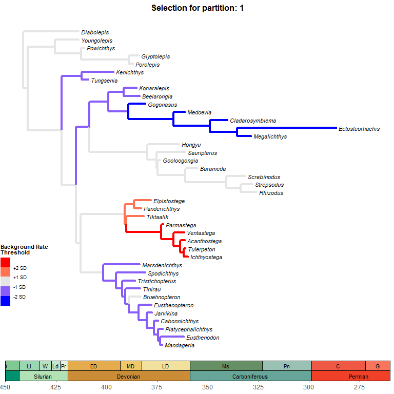

```r
## Plot tree using various thresholds for clock partition 1
A1<- plot_treerates_sgn(tree3p, posterior3p,
                   clock = 1,               #Show rates for clock partition 1
                   summary = "mean",        #sets summary stats to get from summary tree nodes
                   branch_size = 1.5, tip_size = 3,                      #sets size for tree elements
                   xlim=c(-450,-260), nbreaks = 8, geo_size=list(3, 3),  #sets limits and breaks for geoscale
                   threshold = c("1 SD", "2 SD"))                 #sets threshold for selection mode
A1
```

Plot tree using various thresholds for other clock partition and combine them

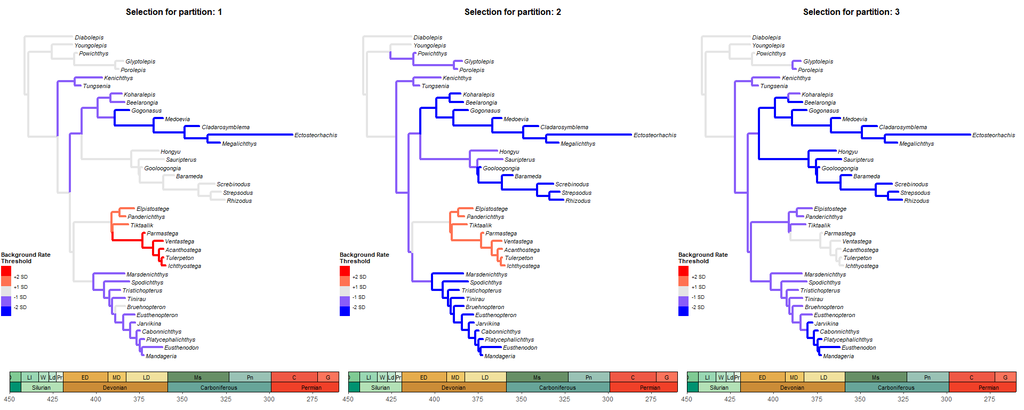

```r
## Plot tree using various thresholds for other clock partition and combine them
A2<-plot_treerates_sgn(tree3p, posterior3p,
                   clock = 2,               #Show rates for clock partition 2
                   summary = "mean",        #sets summary stats to get from summary tree nodes
                   branch_size = 1.5, tip_size = 3,                      #sets size for tree elements
                   xlim=c(-450,-260), nbreaks = 8, geo_size=list(3, 3),  #sets limits and breaks for geoscale
                   threshold = c("1 SD", "2 SD"))                 #sets threshold for selection mode

A3<-plot_treerates_sgn(tree3p, posterior3p,
                   clock = 3,               #Show rates for clock partition 2
                   summary = "mean",        #sets summary stats to get from summary tree nodes
                   branch_size = 1.5, tip_size = 3,                      #sets size for tree elements
                   xlim=c(-450,-260), nbreaks = 8, geo_size=list(3, 3),  #sets limits and breaks for geoscale
                   threshold = c("1 SD", "2 SD"))                 #sets threshold for selection mode

A1|A2|A3
```

```r
##(NOT RUN)
## Save your plot to your working directory as a PDF
#ggplot2::ggsave    ("Tree_Sel_3p.pdf", width=20, height=8)
```

## References

Baker, Joanna, Andrew Meade, Mark Pagel, and Chris Venditti. 2016. “Positive Phenotypic Selection Inferred from Phylogenies.” *Biological Journal of the Linnean Society* 118 (1): 95–115.

Simões, Tiago R., and Stephanie E. Pierce. 2021. “Sustained High Rates of Morphological Evolution During the Rise of Tetrapods.” *Nature Ecology & Evolution* 5 (10): 1403–14. https://doi.org/10.1038/s41559-021-01532-x.